# Lab 4: MATH 4753

Joshua Wiseman

February 10, 2023

# Tasks

### My Brain in STATS rn

*ROCK AND ROLL MAN!!!*

[figure not shown]

## Task 1

### Working Directory

```r
getwd()
```

```
## [1] "/home/joshua/Desktop/MainFolder/OuClasses/Spring 2023/Applied Statistical Methods/FALL224753wise0046/LABS/LAB4"
```

## Task 2

### Loading the Spruce Data File

```r
spruce.df = read.csv("SPRUCE.csv")
tail(spruce.df)
```

```
##    BHDiameter Height
## 31       17.7   19.9
## 32       20.7   19.4
## 33       21.0   20.4
## 34       13.3   15.5
## 35       15.9   17.6
## 36       22.9   19.2
```

## Task 3

### Lowess Smoother Scatter Plot

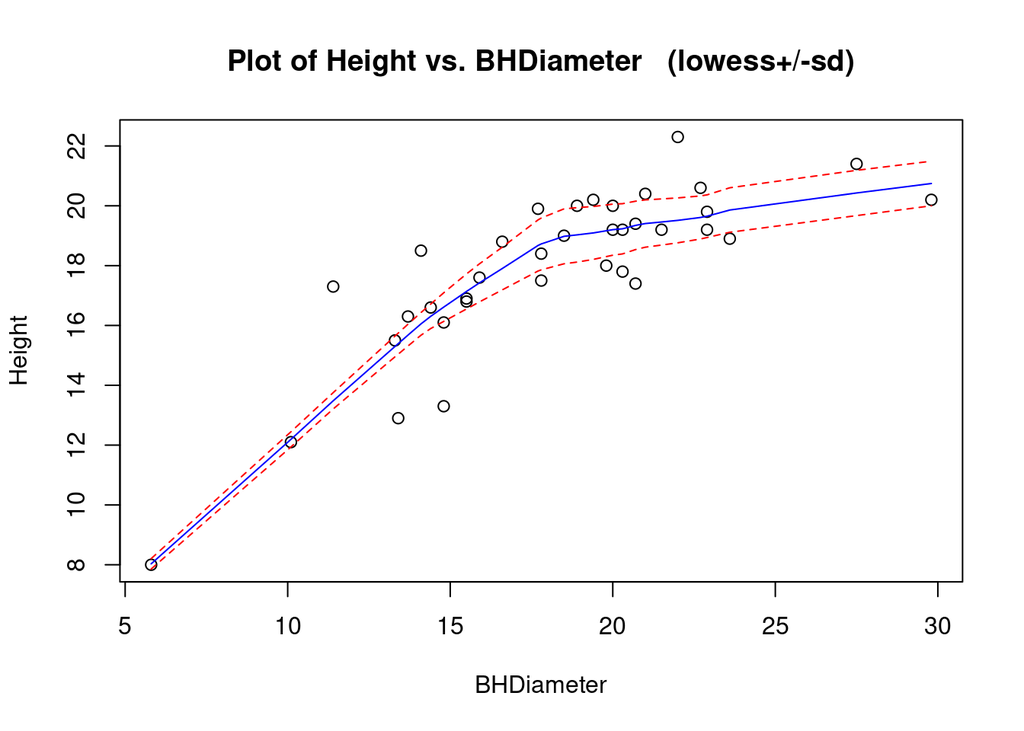

```r
library(s20x)
trendscatter(Height~BHDiameter, data = spruce.df, f = 0.5)
```

### Linear Model Object

```r
spruce.lm = with(spruce.df, lm(Height~BHDiameter))
summary(spruce.lm)
```

```
##
## Call:
## lm(formula = Height ~ BHDiameter)
##
## Residuals:
##     Min      1Q  Median      3Q     Max
## -3.9394 -0.9763  0.2829  0.9950  2.6644
##
## Coefficients:
##             Estimate Std. Error t value Pr(>|t|)
## (Intercept)  9.14684    1.12131   8.157 1.63e-09 ***
## BHDiameter   0.48147    0.05967   8.069 2.09e-09 ***
## ---
## Signif. codes:  0 '***' 0.001 '**' 0.01 '*' 0.05 '.' 0.1 ' ' 1
##
## Residual standard error: 1.678 on 34 degrees of freedom
## Multiple R-squared:  0.6569, Adjusted R-squared:  0.6468
## F-statistic:  65.1 on 1 and 34 DF,  p-value: 2.089e-09
```

### Finding Residuals

```r
height.res = residuals(spruce.lm)
```

### Finding Fitted Values

```r
height.fit = fitted(spruce.lm)
```

### Residuals vs Fitted Plot

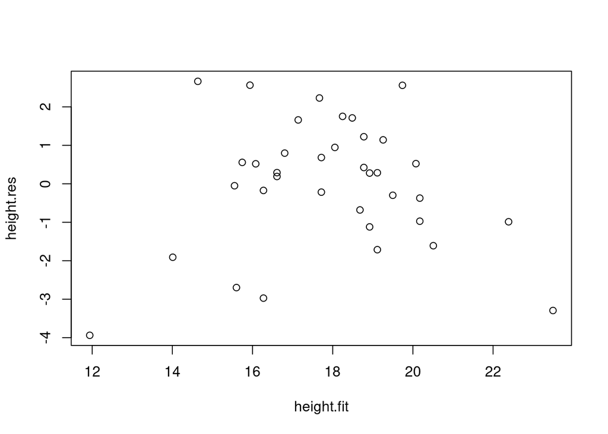

```r
plot(height.res~height.fit)
```

### Residuals vs Fitted Scatter Plot

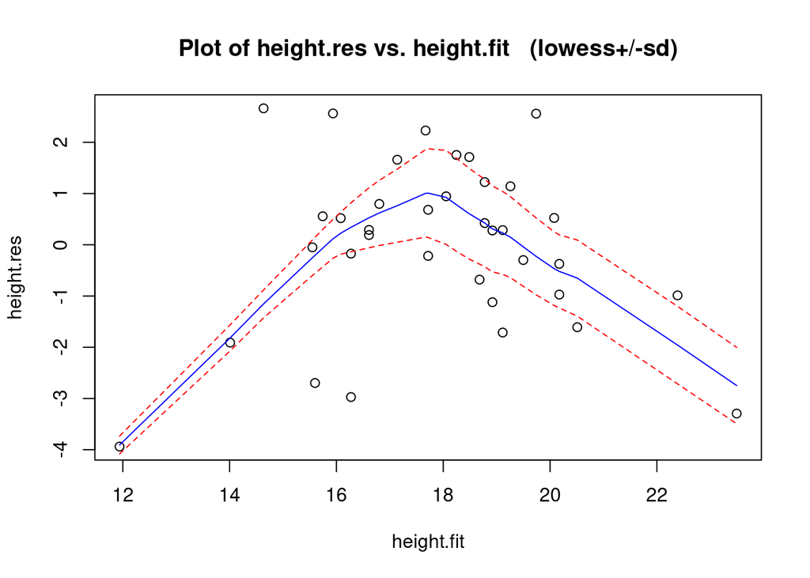

```r
trendscatter(height.res~height.fit)
```

### Shape of the Plot?

What shape is seen in the plot? Compare it with the curve made with the trendscatter function (second line after Task3). `The shape of the Residuals vs Fitted Scatter Plot looks like a mound in` `comparison to a concave exponential curve seen in the Lowess Smoother` `Scatter Plot.`

### Residual Plot

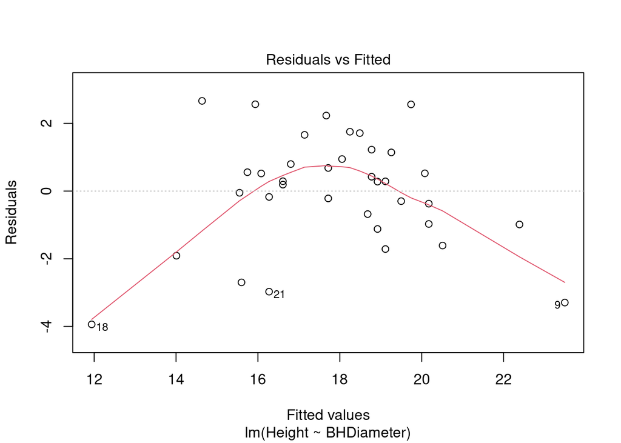

```r
plot(spruce.lm, which = 1)
```

### Check Normality

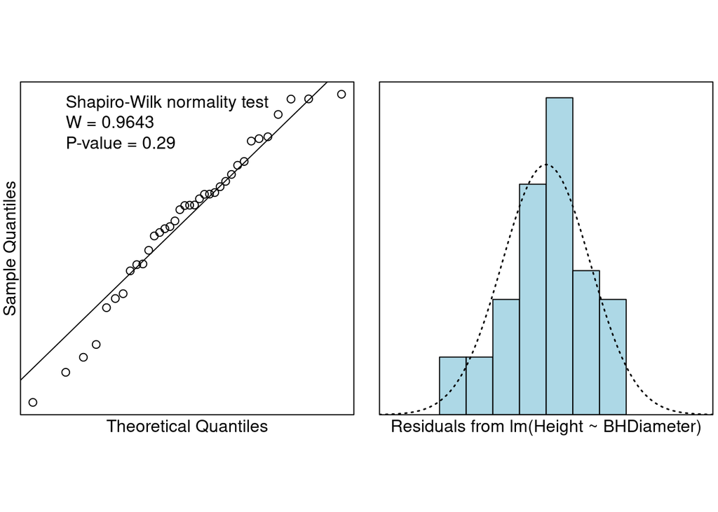

```r
normcheck(spruce.lm, shapiro.wilk = TRUE)
```

### Pvalue for Shapiro-Wilk Test

What is the pvalue for the Shapiro-Wilk test? What is the NULL hypothesis in this case? `The p-value is 0.29. p-value is greater than 0.05, so the null hypothesis` `is accepted that the error is distributed normally.`

### Linear Equation Evaluation

```r
round(mean(height.res), 4)
```

```
## [1] 0
```

### Does the Line work?

Write a sentence outlining your conclusions concerning the validity of applying the straight line to this data set. `No, we shouldn't use a straight line model. The shape of a concave down` `quadratic is different than a straight line by a long shot. Also the` `'noise' of the model is not close to that middle point at all.`

## Task 4

### Quadratic Linear Model

```r
quad.lm = lm(Height~BHDiameter + I(BHDiameter ^ 2),data = spruce.df)
```

### Quadratic Scatter Plot

```r
coef(quad.lm)
```

```
##     (Intercept)      BHDiameter I(BHDiameter^2)
##      0.86089580      1.46959217     -0.02745726
```

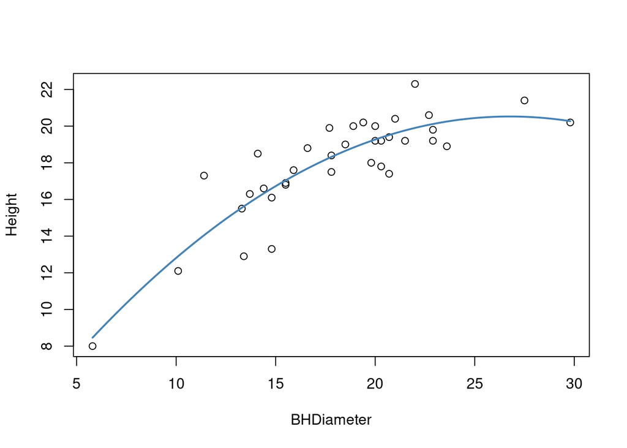

```r
plot(spruce.df)

myplot = function(x){
  quad.lm$coef[1] + quad.lm$coef[2] * x + quad.lm$coef[3] * x ^ 2
}

curve(myplot, lwd = 2, col = "steelblue", add = TRUE)
```

### Fitted Quadratic Model

```r
quad.fit = fitted(quad.lm)
```

### Residuals vs Fitted Plot

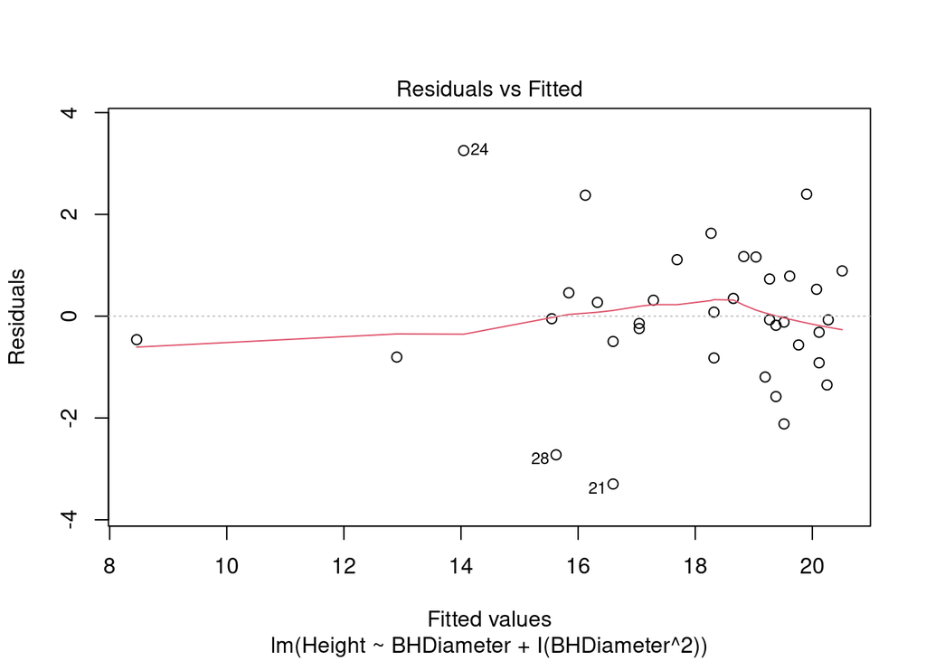

```r
plot(quad.lm, which = 1)
```

### Check Normality

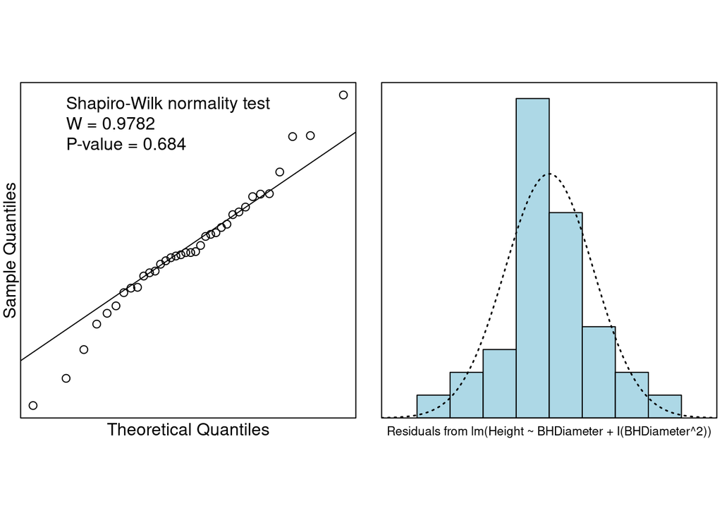

```r
normcheck(quad.lm, shapiro.wilk = TRUE)
```

### Pvalue + Conclusion

What is the value of the p-value in the Shapiro-Wilk test? What do you conclude? `The p-value is 0.684. Therefore the null hypothesis is accepted.` `There is not much of a trend going on, but the 'noise' for this model` `is way better than the previous.`

## Task 5

### Summarize quad.lm

```r
summary(quad.lm)
```

```
##
## Call:
## lm(formula = Height ~ BHDiameter + I(BHDiameter^2), data = spruce.df)
##
## Residuals:
##     Min      1Q  Median      3Q     Max
## -3.2966 -0.6245 -0.0707  0.7442  3.2541
##
## Coefficients:
##                  Estimate Std. Error t value Pr(>|t|)
## (Intercept)      0.860896   2.205022   0.390 0.698731
## BHDiameter       1.469592   0.243786   6.028 8.88e-07 ***
## I(BHDiameter^2) -0.027457   0.006635  -4.138 0.000227 ***
## ---
## Signif. codes:  0 '***' 0.001 '**' 0.01 '*' 0.05 '.' 0.1 ' ' 1
##
## Residual standard error: 1.382 on 33 degrees of freedom
## Multiple R-squared:  0.7741, Adjusted R-squared:  0.7604
## F-statistic: 56.55 on 2 and 33 DF,  p-value: 2.182e-11
```

### Beta Hat Values

$$\beta_0 = 0.860896$$
$$\beta_1 = 1.469592$$
$$\beta_2 = -0.027457$$

### Interval Estimates

```r
ciReg(quad.lm)
```

```
##                 95 % C.I.lower    95 % C.I.upper
## (Intercept)           -3.62525           5.34705
## BHDiameter             0.97361           1.96558
## I(BHDiameter^2)       -0.04096          -0.01396
```

### Fitted Line Equation

$$0.860896 + 1.469592x -
0.027457x^2$$

### Height Predictions

```r
predict(quad.lm, data.frame(BHDiameter = c(15, 18, 20)))
```

```
##        1        2        3
## 16.72690 18.41740 19.26984
```

### Comparison

```r
predict(spruce.lm, data.frame(BHDiameter = c(15, 18, 20)))
```

```
##        1        2        3
## 16.36895 17.81338 18.77632
```

### Multiple R-squared

```r
# Previous Model
RSS1 = with(spruce.df, sum((Height-height.fit)^2))
MSS1 = with(spruce.df, sum((height.fit-mean(Height))^2))
TSS1 = with(spruce.df, sum((Height-mean(Height))^2))
R1 = MSS1/TSS1
R1
```

```
## [1] 0.6569146
```

```r
# Current Model
RSS2 = with(spruce.df, sum((Height-quad.fit)^2))
MSS2 = with(spruce.df, sum((quad.fit-mean(Height))^2))
TSS2 = with(spruce.df, sum((Height-mean(Height))^2))
R2 = MSS2/TSS2
R2
```

```
## [1] 0.7741266
```

### Adjusted R squared

###### Adjusted R-squared for Current Model: 0.7604

###### Adjusted R-squared for Previous Model: 0.6468

The closer R^2 is to 1 the better, so the Current Model is “better”.

### Multiple R^2 Meaning

What does multiple $R^2$ mean in this case? `This means the how close of a fit is the data to the line of the model.` `1 meaning all data points are on the line & 0 mean no data points are` `on the line.`

### Best Model for Height

```r
data = 15:24
predict20x(quad.lm,data.frame(BHDiameter = data, `I(BHDiameter)^2`=data^2))
```

```
##    Predicted  Conf.lower Conf.upper  Pred.lower  Pred.upper
## 1     16.727      16.133     17.321      13.854      19.600
## 2     17.345      16.773     17.917      14.477      20.214
## 3     17.909      17.348     18.469      15.042      20.775
## 4     18.417      17.862     18.972      15.552      21.283
## 5     18.871      18.318     19.424      16.006      21.736
## 6     19.270      18.712     19.827      16.404      22.136
## 7     19.614      19.040     20.187      16.745      22.483
## 8     19.903      19.294     20.511      17.026      22.779
## 9     20.137      19.464     20.809      17.246      23.027
## 10    20.316      19.546     21.085      17.401      23.230
```

```r
predict20x(spruce.lm,data.frame(BHDiameter = data))
```

```
##    Predicted  Conf.lower Conf.upper  Pred.lower  Pred.upper
## 1     16.369      15.681     17.057      12.891      19.847
## 2     16.850      16.223     17.478      13.384      20.317
## 3     17.332      16.745     17.918      13.872      20.792
## 4     17.813      17.245     18.382      14.357      21.270
## 5     18.295      17.718     18.871      14.837      21.753
## 6     18.776      18.167     19.385      15.313      22.240
## 7     19.258      18.596     19.920      15.785      22.731
## 8     19.739      19.007     20.471      16.252      23.226
## 9     20.221      19.407     21.034      16.715      23.726
## 10    20.702      19.798     21.607      17.175      24.230
```

### Anova Comparison + Conclusion

```r
anova(spruce.lm)
```

```
## Analysis of Variance Table
##
## Response: Height
##            Df  Sum Sq Mean Sq F value    Pr(>F)
## BHDiameter  1 183.245 183.245  65.101 2.089e-09 ***
## Residuals  34  95.703   2.815
## ---
## Signif. codes:  0 '***' 0.001 '**' 0.01 '*' 0.05 '.' 0.1 ' ' 1
```

```r
anova(quad.lm)
```

```
## Analysis of Variance Table
##
## Response: Height
##                 Df  Sum Sq Mean Sq F value    Pr(>F)
## BHDiameter       1 183.245 183.245  95.975 2.701e-11 ***
## I(BHDiameter^2)  1  32.696  32.696  17.125 0.0002269 ***
## Residuals       33  63.007   1.909
## ---
## Signif. codes:  0 '***' 0.001 '**' 0.01 '*' 0.05 '.' 0.1 ' ' 1
```

```r
anova(spruce.lm, quad.lm)
```

```
## Analysis of Variance Table
##
## Model 1: Height ~ BHDiameter
## Model 2: Height ~ BHDiameter + I(BHDiameter^2)
##   Res.Df    RSS Df Sum of Sq      F    Pr(>F)
## 1     34 95.703
## 2     33 63.007  1    32.696 17.125 0.0002269 ***
## ---
## Signif. codes:  0 '***' 0.001 '**' 0.01 '*' 0.05 '.' 0.1 ' ' 1
```

From this comparison, we can conclude that the Current Model is better than this previous because the pvalue 0.0002269 *** is against H_0: beta2 = 0.

### TSS + MSS + RSS

```r
#Previous Model
TSS1
```

```
## [1] 278.9475
```

```r
MSS1
```

```
## [1] 183.2447
```

```r
RSS1
```

```
## [1] 95.70281
```

```r
# Current Model
TSS2
```

```
## [1] 278.9475
```

```r
MSS2
```

```
## [1] 215.9407
```

```r
RSS2
```

```
## [1] 63.00683
```

### MSS/TSS

```r
# Previous Model
MSS1/TSS2
```

```
## [1] 0.6569146
```

```r
# CUrrent Model
MSS2/TSS2
```

```
## [1] 0.7741266
```

## Task 6

### Cooks Plot

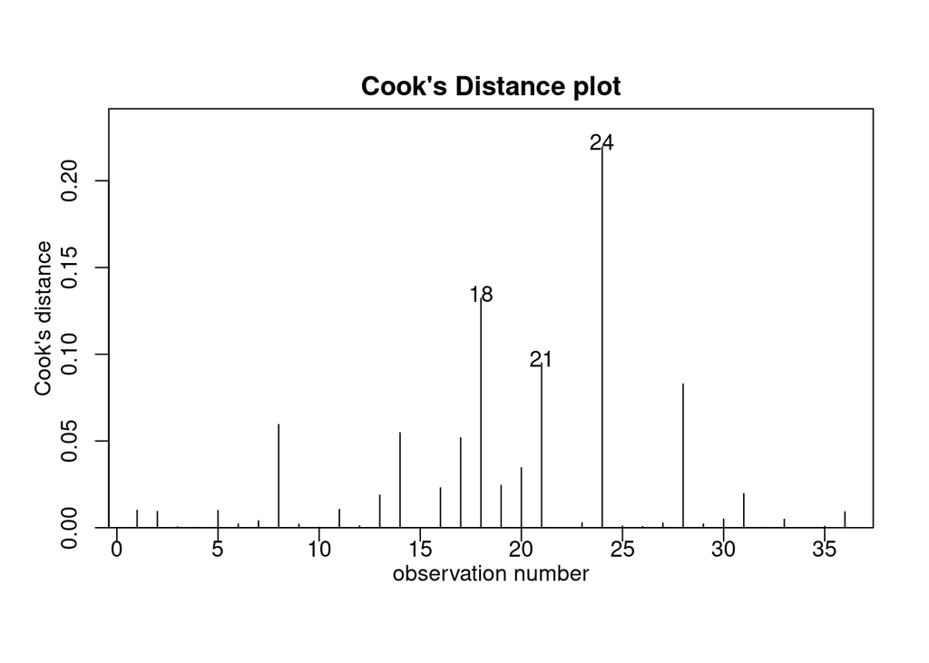

```r
cooks20x(quad.lm)
```

### Making quad2.lm

```r
quad2.lm=lm(Height~BHDiameter + I(BHDiameter^2) , data=spruce.df[-24,])
```

### Summarize quade.lm

```r
summary(quad2.lm)
```

```
##
## Call:
## lm(formula = Height ~ BHDiameter + I(BHDiameter^2), data = spruce.df[-24,
##     ])
##
## Residuals:
##      Min       1Q   Median       3Q      Max
## -3.11233 -0.48227  0.01253  0.71727  2.59146
##
## Coefficients:
##                  Estimate Std. Error t value Pr(>|t|)
## (Intercept)     -0.341500   2.068479  -0.165     0.87
## BHDiameter       1.564793   0.226102   6.921 7.78e-08 ***
## I(BHDiameter^2) -0.029242   0.006114  -4.782 3.74e-05 ***
## ---
## Signif. codes:  0 '***' 0.001 '**' 0.01 '*' 0.05 '.' 0.1 ' ' 1
##
## Residual standard error: 1.266 on 32 degrees of freedom
## Multiple R-squared:  0.8159, Adjusted R-squared:  0.8044
## F-statistic: 70.91 on 2 and 32 DF,  p-value: 1.74e-12
```

### Conclusion

The action in getting rid of data with the highest datum cooks distance has resulted in a more accurate model. The reason being R^2 has increased even further to 0.8159.

## Task 7

### Proof

Prove using latex that $y=\beta_0+\beta_1x+\beta_2(x-x_k)I(x>x_k)$ where I() is 1 when $x>x_k$ and 0 else.

Suppose that for line 1 and line 2 we have the following formula

We will introduce an indicator function that will be 1 when $x>x_k$ and 0 else.

So
$$y = \beta_0 + \beta_1x +
\zeta(x-x_k)I(x>x_k)$$

### Reproduce Plot

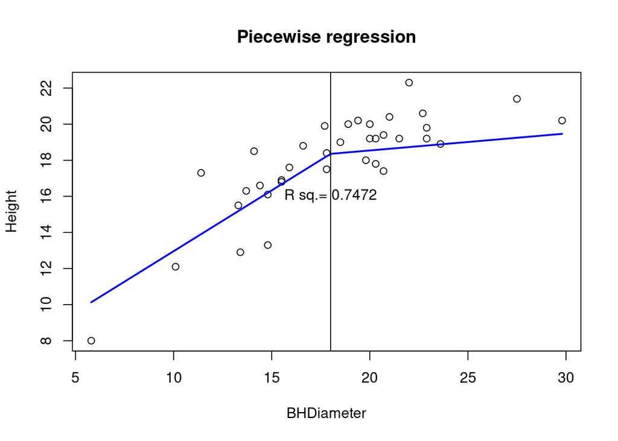

```r
sp2.df = within(spruce.df, X<-(BHDiameter-20)*(BHDiameter>20))

lmp=lm(Height~BHDiameter + X,data=sp2.df)
tmp=summary(lmp)
myf = function(x,coef){
  coef[1]+coef[2]*(x) + coef[3]*(x-18)*(x-18>0)
}
plot(spruce.df,main="Piecewise regression")
curve(myf(x,coef=tmp$coefficients[,"Estimate"] ),add=TRUE, lwd=2,col="Blue")
abline(v=18)
text(18,16,paste("R sq.=",round(tmp$r.squared,4) ))
```

## Task 8

### Load Custom Package

```r
library(BestRPackage)
z = myz(1:4)
z
```

```
## [1] -1.1618950 -0.3872983  0.3872983  1.1618950
```

This is myz function that I made and imported from BestRPackage (my personal package). Why? Because this is the BEST R PACKAGE of course! But what does myz function do? Well, it converts a vector of values to a vector of z-score values, which helps finds outliers in a data set.